# Conclusion Of The Analysis on Ford Go Bike Trips

## Investigation Overview

In this investigation, I wanted to look at what is effects of the trip duration generally, additionally, the correlation of the users considering the age of them.

## Dataset Overview

The data set contain a large value of trip which is 183,412. Looking at the common features in the data, we will find that there is a correlation between trips, stations, and varying ages. that what we will discuss in the following points

### Distribution Upon The Trip Durations

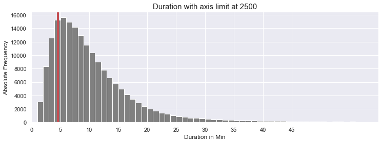

### The Duration Reliance On The Gender

Though quantity of male riders are very high then other and female but we can see that higher percentage of female and other rides longer trips then males.

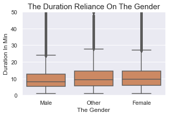

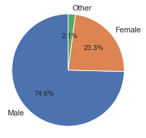

### Correlation Between Trip Durations And Age

Most of the users of the bikes are between 20 and 45 years old additionally the longest period occurred from younger users

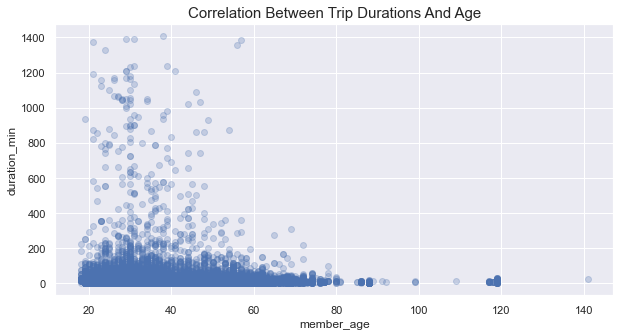

The quantity of young riders are very high than the older, the mentioned chart proof that higher percentage of younger share most of the trip.

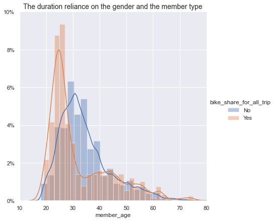

### Top Ten (Start-End) Stations

According to the following, the top ten start station and top ten end stations of our dataset, Market St. and San Francisco stations are the top Start and end stations

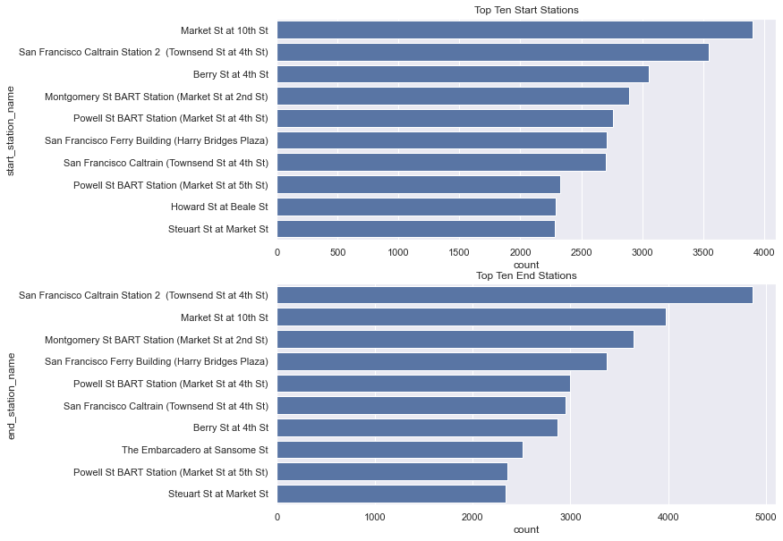